# Lab Warm-up: Confounding

# Load packages

Remember, it’s considered a best practice to load all the packages that your file will use up at the top of the file. If you have not yet installed a package, you will need to do so by running `install.packages("package name")` in the R console. For example, to install the `dplyr` package, you would run `install.packages("dplyr")`. However, you typically **do not** want to type the code to install the package here in your Rmd file. That is because you only need to install the package once on a given computer. Not every time you run your R code.

```r
library(dplyr, warn.conflicts = FALSE) # The "warn.conflicts" part is optional
library(ggplot2)
library(broom)
library(freqtables)
library(meantables)
library(dagitty)
library(ggdag, warn.conflicts = FALSE)
```

# Overview

The code below contains examples to help us learn about confounding.

# Ice cream and murder rates

We just discussed a classic example of confounding – ice cream sales and murder. Let’s take a look at some simulated data designed to recreate this scenario.

First, we will create temperature. We will make it normally distributed with a mean of 50 and a standard deviation of 12.

```r
# Random number seed so that we can reproduce our results
set.seed(123)

# Sample size
n <- 10000

# Create z - temperature
df_ice_cream <- tibble(temperature = rnorm(n, 50, 12))
```

And here is what our temperature data looks like in a histogram.

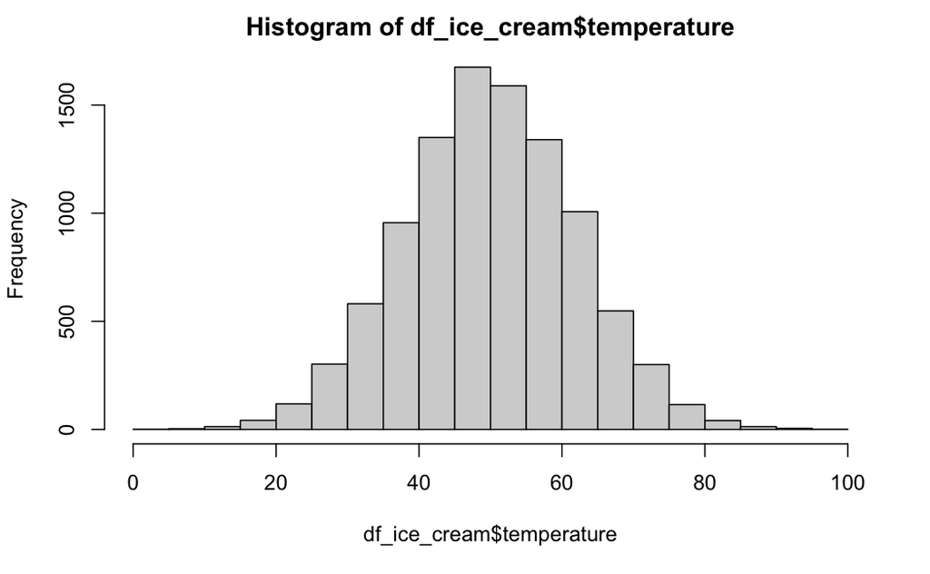

```r
hist(df_ice_cream$temperature)
```

Now, let’s create ice cream sales. In the code below, the values of ice_cream are only determined by our random number generator and the value of temperature. They are totally oblivious to the values of murder. In fact, the murder variable doesn’t even exist yet.

```r
set.seed(234)
sd <- 100
df_ice_cream <- df_ice_cream %>%
  mutate(
    ice_cream = case_when(
      temperature < 20 ~ rnorm(n, 100, sd),
      temperature < 40 ~ rnorm(n, 300, sd),
      temperature < 60 ~ rnorm(n, 500, sd),
      temperature < 80 ~ rnorm(n, 800, sd),
      temperature < 100 ~ rnorm(n, 1000, sd),
      temperature > 100 ~ rnorm(n, 1200, sd),
    )
  )
```

And here is what our ice cream sales data looks like in a histogram.

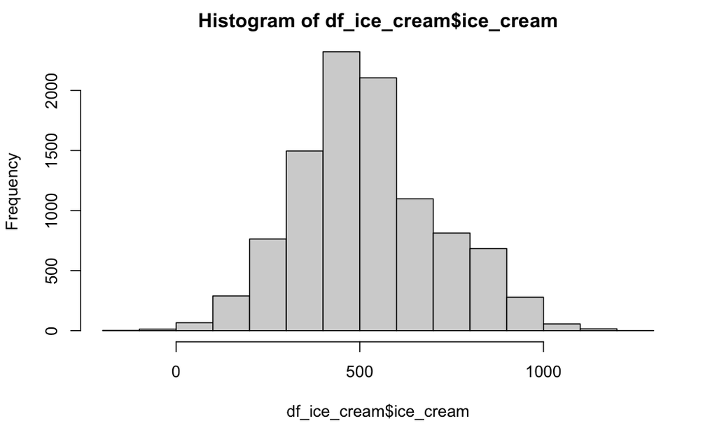

```r
hist(df_ice_cream$ice_cream)
```

Finally, let’s create the murder variable. In the code below, the values of murder are only determined by our random number generator and the value of temperature. They are totally oblivious to the values of ice cream sales.

```r
set.seed(456)
sd <- 5
df_ice_cream <- df_ice_cream %>%
  mutate(
    murder = case_when(
      temperature < 20 ~ rnorm(n, 20, sd),
      temperature < 40 ~ rnorm(n, 30, sd),
      temperature < 60 ~ rnorm(n, 40, sd),
      temperature < 80 ~ rnorm(n, 50, sd),
      temperature < 100 ~ rnorm(n, 60, sd),
      temperature > 100 ~ rnorm(n, 70, sd),
    )
  )

# Change negative murder rates to 0
df_ice_cream <- mutate(df_ice_cream, murder = if_else(murder < 0, 0, murder))
```

And here is what our murder data looks like in a histogram.

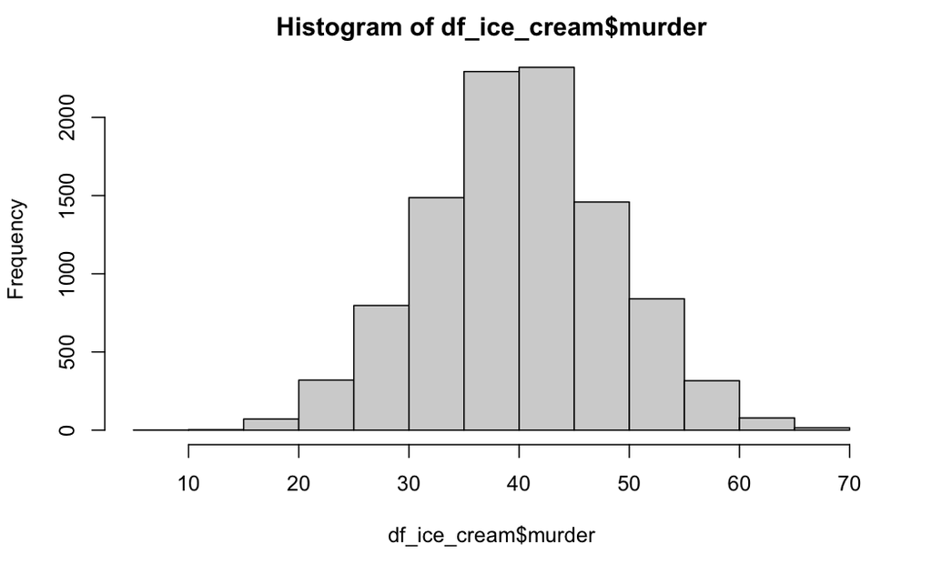

```r
hist(df_ice_cream$murder)
```

We know that there is no causal relationship between ice_cream and murder because we created them both. * The value of ice_cream is only determined by temperature, not by murders. * The value of murder is only determined by temperature, not by ice cream sales.

Therefore, we might naively expect there to be *NO* correlation between ice cream sales and murder.

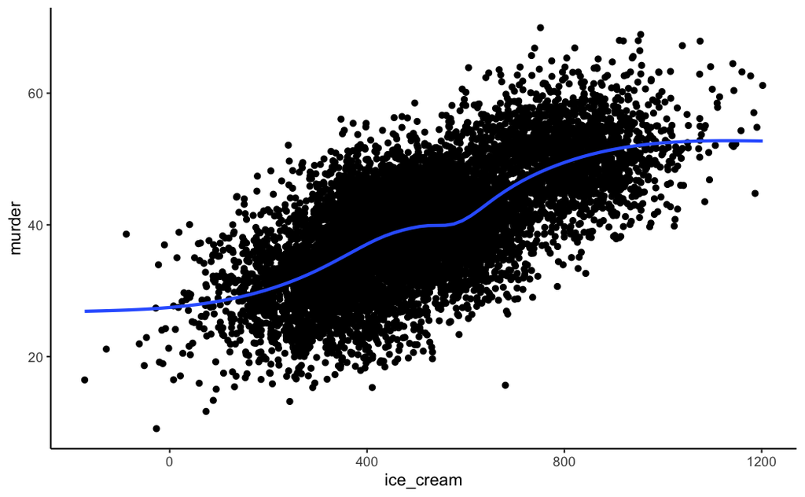

```r
ggplot(df_ice_cream, aes(ice_cream, murder)) +
  geom_point() +
  geom_smooth(se = FALSE) +
  theme_classic()
```

However, there is an obvious correlation between in the data when we view it as a scatter plot. As ice cream sales rise, so do the number of murders, on average.

```r
cor.test(df_ice_cream$ice_cream, df_ice_cream$murder)
```

```
    Pearson's product-moment correlation

data:  df_ice_cream$ice_cream and df_ice_cream$murder
t = 90.83, df = 9998, p-value < 2.2e-16
alternative hypothesis: true correlation is not equal to 0
95 percent confidence interval:
 0.6615074 0.6829886
sample estimates:
      cor
0.6723896
```

Further, our Pearson’s correlation coefficient (0.67) indicates that ice cream sales and murder are highly positively correlated in our population.

Again, the association between ice cream sales and murder is a real, valid association. It just doesn’t represent a causal effect. Rather, it’s purely due to the fact that ice cream sales and murder share a common cause – temperature.

# Regression adjustment

Perhaps the most common way to control for confounding is to add a sufficient set of deconfounders to our regression models. In the following examples, we will demonstrate how to add multiple variables to our regression models in R, and how to interpret our results.

## Multiple linear regression - continuous regressand

```r
glm(
  ice_cream ~ murder,
  gaussian(link = "identity"),
  df_ice_cream
) %>%
  tidy()
```

| term | estimate | std.error | statistic | p.value |
| --- | --- | --- | --- | --- |
| (Intercept) | -95.16709 | 6.9305710 | -13.73149 | 1.597097e-42 |
| murder | 15.37007 | 0.1692178 | 90.83013 | 0.000000e+00 |

### Interpretation

- On average, the mean value of ice cream sales is approximately -$95.20 on days when zero murders occur.
- Ice cream sales increase by an average of $15.40 for each additional occurrence of murder.

```r
glm(
  ice_cream ~ murder + temperature,
  gaussian(link = "identity"),
  df_ice_cream
) %>%
  tidy()
```

| term | estimate | std.error | statistic | p.value |
| --- | --- | --- | --- | --- |
| (Intercept) | -178.972040 | 6.0443678 | -29.60972 | 9.070816e-185 |
| murder | 6.292628 | 0.2052953 | 30.65159 | 2.791095e-197 |
| temperature | 8.957335 | 0.1445423 | 61.97035 | 0.000000e+00 |

### Interpretation

- On average, the mean value of ice cream sales is approximately -$178.97 on days when zero murders occur after adjusting for temperature.
- Ice cream sales increase by an average of $6.29 for each additional occurrence of murder after adjusting for temperature.

Why isn’t it zero?

Let’s simulate our data in a different way this time.

```r
set.seed(123)
n <- 10000
df_ice_cream_2 <- tibble(
  temperature = rnorm(n, 50, 12),
  ice_cream   = 500 + (20 * temperature) + rnorm(n, 0, 20),
  murder      = 5 + (1.5 * temperature) + (0 * ice_cream) + rnorm(n, 0, 16)
)
```

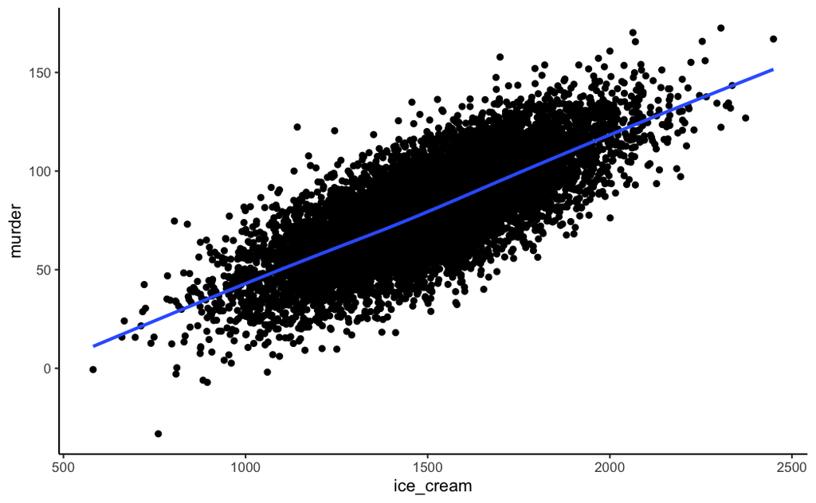

```r
ggplot(df_ice_cream_2, aes(ice_cream, murder)) +
  geom_point() +
  geom_smooth(se = FALSE) +
  theme_classic()
```

Let’s draw a sample of 100 people from our simulated population.

```r
set.seed(123)
ice_cream_sample <- sample_n(df_ice_cream_2, 100)
```

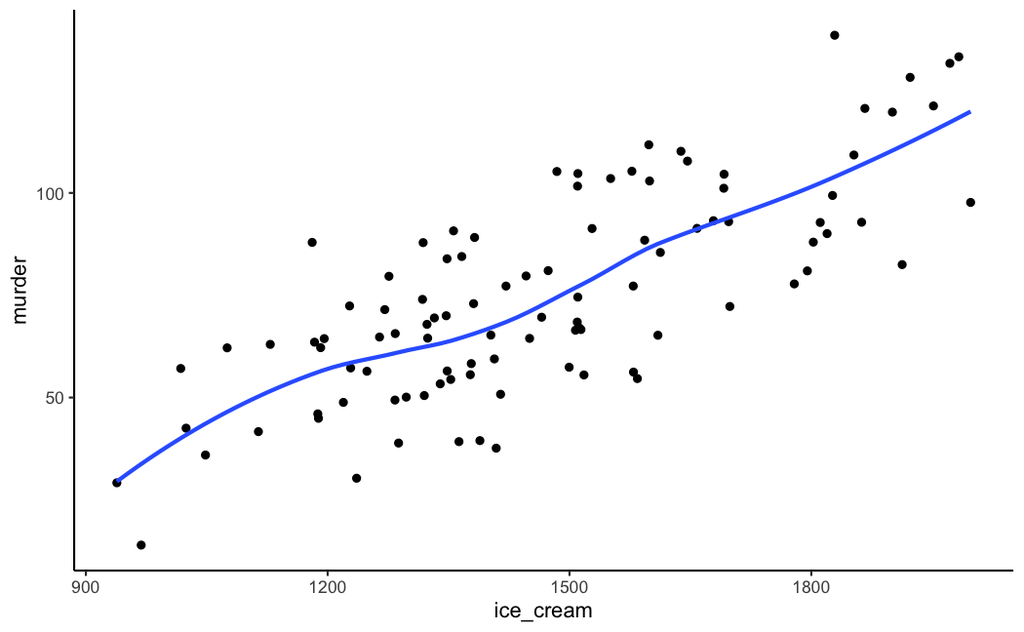

```r
ggplot(ice_cream_sample, aes(ice_cream, murder)) +
  geom_point() +
  geom_smooth(se = FALSE) +
  theme_classic()
```

Estimate the relationship between variables, given our model assumptions.

```r
glm(
  ice_cream ~ murder,
  gaussian(link = "identity"),
  ice_cream_sample
) %>%
  tidy()
```

| term | estimate | std.error | statistic | p.value |
| --- | --- | --- | --- | --- |
| (Intercept) | 900.959582 | 51.0158572 | 17.66038 | 3.255532e-32 |
| murder | 7.538487 | 0.6419826 | 11.74251 | 2.120312e-20 |

### Interpretation

- On average, the mean value of ice cream sales is approximately $900.96 on days when zero murders occur.
- Ice cream sales increase by an average of $7.54 for each additional occurrence of murder.

```r
glm(
  ice_cream ~ murder + temperature,
  gaussian(link = "identity"),
  ice_cream_sample
) %>%
  tidy(conf.int = TRUE)
```

| term | estimate | std.error | statistic | p.value | conf.low | conf.high |
| --- | --- | --- | --- | --- | --- | --- |
| (Intercept) | 487.6731284 | 7.9213124 | 61.564688 | 1.492079e-79 | 472.1476412 | 503.19861546 |
| murder | -0.2164898 | 0.1218771 | -1.776296 | 7.881963e-02 | -0.4553645 | 0.02238498 |
| temperature | 20.5928365 | 0.2510353 | 82.031651 | 2.047633e-91 | 20.1008164 | 21.08485652 |

### Interpretation

- On average, the mean value of ice cream sales is approximately $487.67 on days when zero murders occur after adjusting for temperature.
- Ice cream sales decrease by an average of $0.22 for each additional occurrence of murder after adjusting for temperature.
- Null hypothesis for murder: The true difference in ice cream sales for each one unit increase in murder is zero dollars.
- Test statistic is -1.78
- The probability of finding a test statistic at least as extreme as -1.78 if all of the model assumptions are correct is 0.079.
- The confidence limits indicate that these data are highly compatible with estimates between -0.46 and 0.02 dollars— assuming that the statistical model used to construct the limits is correct and that our estimates were free from bias.

Now, let’s draw a sample of 500 people from our simulated population.

```r
set.seed(123)
ice_cream_sample <- sample_n(df_ice_cream_2, 500)
```

```r
glm(
  ice_cream ~ murder + temperature,
  gaussian(link = "identity"),
  ice_cream_sample
) %>%
  tidy(conf.int = TRUE)
```

| term | estimate | std.error | statistic | p.value | conf.low | conf.high |
| --- | --- | --- | --- | --- | --- | --- |
| (Intercept) | 492.75952794 | 4.10855147 | 119.935099 | 0.0000000 | 484.7069150 | 500.81214084 |
| murder | -0.06774386 | 0.05753441 | -1.177449 | 0.2395797 | -0.1805092 | 0.04502151 |
| temperature | 20.23433937 | 0.11637808 | 173.867277 | 0.0000000 | 20.0062425 | 20.46243621 |

### Interpretation

- On average, the mean value of ice cream sales is approximately $492.76 on days when zero murders occur after adjusting for temperature.
- Ice cream sales decrease by an average of $0.07 for each additional occurrence of murder after adjusting for temperature.
- Null hypothesis for murder: The true difference in ice cream sales for each one unit increase in murder is zero dollars.
- Test statistic is -1.18
- The probability of finding a test statistic at least as extreme as -1.18 if all of the model assumptions are correct is 0.24.
- The confidence limits indicate that these data are highly compatible with estimates between -0.18 and 0.05 dollars— assuming that the statistical model used to construct the limits is correct and that our estimates were free from bias.

## Multiple linear regression - categorical regressor

```r
set.seed(123)
n <- 10000
df_ice_cream_3 <- tibble(
  summer    = rbinom(n, 1, .30),
  ice_cream = 500 + (700 * summer) + rnorm(n, 0, 20),
  murder    = 5 + (100 * summer) + (0 * ice_cream) + rnorm(n, 0, 16),
  summer_f  = factor(summer, 0:1, c("No", "Yes"))
)
```

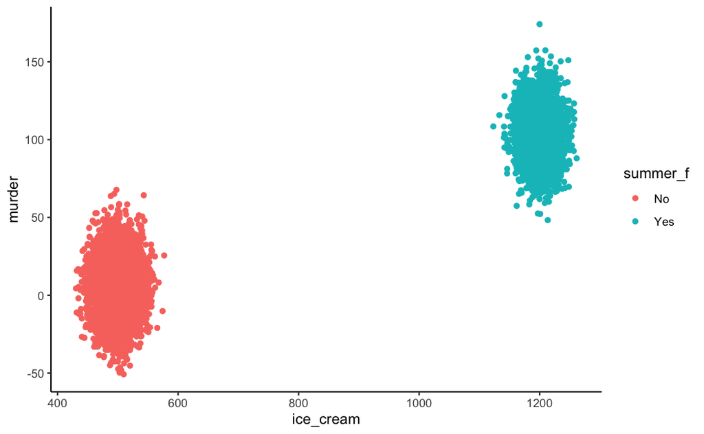

```r
ggplot(df_ice_cream_3, aes(ice_cream, murder, color = summer_f)) +
  geom_point() +
  theme_classic()
```

Now, let’s draw a sample of 500 people from our simulated population.

```r
set.seed(123)
ice_cream_sample <- sample_n(df_ice_cream_3, 500)
```

```r
glm(
  ice_cream ~ murder + summer_f,
  gaussian(link = "identity"),
  ice_cream_sample
) %>%
  tidy(conf.int = TRUE)
```

| term | estimate | std.error | statistic | p.value | conf.low | conf.high |
| --- | --- | --- | --- | --- | --- | --- |
| (Intercept) | 501.19233409 | 1.03205257 | 485.6267478 | 0.0000000 | 499.16954821 | 503.2151200 |
| murder | 0.02201874 | 0.05339219 | 0.4123963 | 0.6802268 | -0.08262804 | 0.1266655 |
| summer_fYes | 694.89232901 | 5.55881515 | 125.0072741 | 0.0000000 | 683.99725152 | 705.7874065 |

### Interpretation

- On average, the mean value of ice cream sales is approximately $501.19 on days when zero murders occur after adjusting for summer season.
- Ice cream sales increase by an average of $0.02 for each additional occurrence of murder after adjusting for summer season.
- Null hypothesis for murder: The true difference in ice cream sales for each one unit increase in murder is zero dollars.
- Test statistic is 0.4
- The probability of finding a test statistic at least as extreme as 0.40 if all of the model assumptions are correct is 0.68.
- The confidence limits indicate that these data are highly compatible with estimates between -0.08 and 0.13 dollars — assuming that the statistical model used to construct the limits is correct and that our estimates were free from bias.